# Assessing the biotic communities in rivers across the Greater Toronto Area, ON, Canada

Last compiled on 25 June, 2022

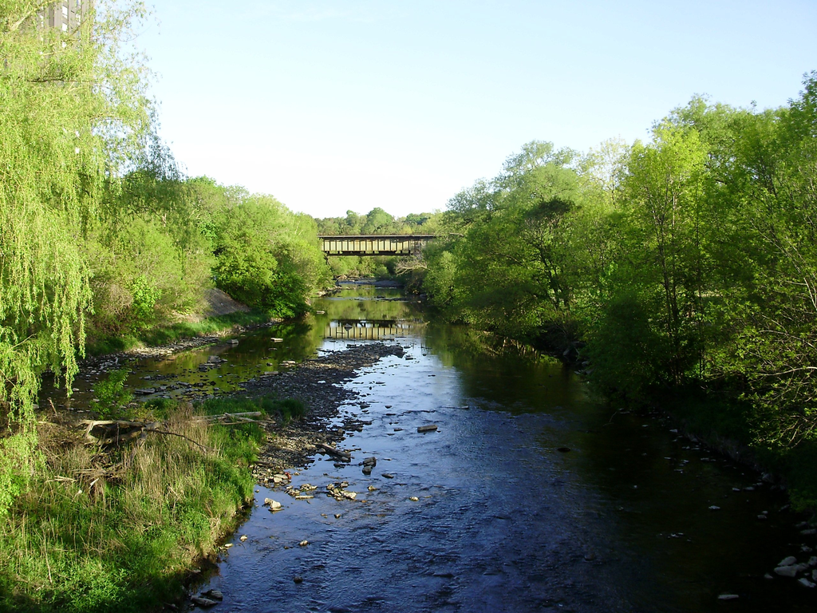

Etobicoke Creek, Toronto, Ontario, Canada

# 1 Introduction

As per previous investigations (Bazinet et al 2010), there is evidence to suggest that the increasing urbanization in the Greater Toronto Area correlates with a decrease in biotic community population and diversity across affected lotic systems. Therefore, as part of this investigation, a thorough analysis of watersheds extending from Etobicoke to Ajax was conducted and subsequently, assessed in conjunction with the previous results and surveys (Wallace et al 2013).

First, we establish the datasets we will be using, of which we have many. Data from the Toronto Regional Council Authority website has open access data as far back as 2013 for our intended purposes. With this, we have completed an detailed analysis of Macroinvertebrate diversity with a focus on sensitive taxa as well as potential environmental stressors including temperature and dissolved oxygen using the appropriate reference guides and methodologies where possible. The analysis techniques used in this analysis were derived from previously utilized methods from past reports in order to maintain relative comparability. Following, a brief discussion regarding the results of current and past trends is provided. Finally, a conclusion to round out how to improve the watersheds, if necessary will be brought to attention.

As per the data that was taken from the Toronto and Region Greater Conservation Authority, figure 1 shows the testing sites across the Toronto region for the data taken.

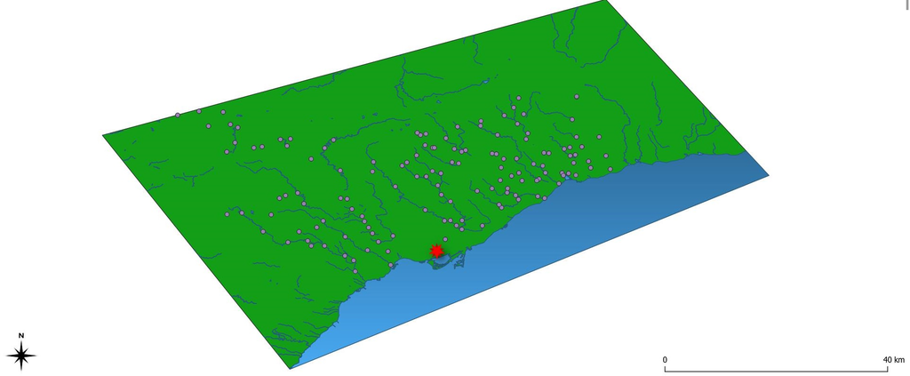

*Figure 1. Map of the Greater Toronto Region and recorded macroinvertebrate survey sites between 2013 and 2020.*

# 2 Macroinvertebrate Counts

Using the data over the period 2013-2020, Shannon-Wiener index will be used to determine the diversity of macroinvertebrate communities in the GTA Region.

$$H = -\sum_{i = 1}^{S}{P_iln(P_i)}$$
*Figure 2. Shannon-Weiner Index for the surveyed creeks in the Greater Toronto Area, 2013 - 2020*

H = Shannon diversity index S = Number of Species Present P = proportion (n/N) of individuals of a species (n) found divided by the total number of individuals found (N) ln = Natural Log E = Summation of the following equation

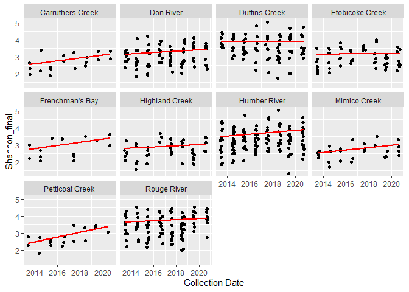

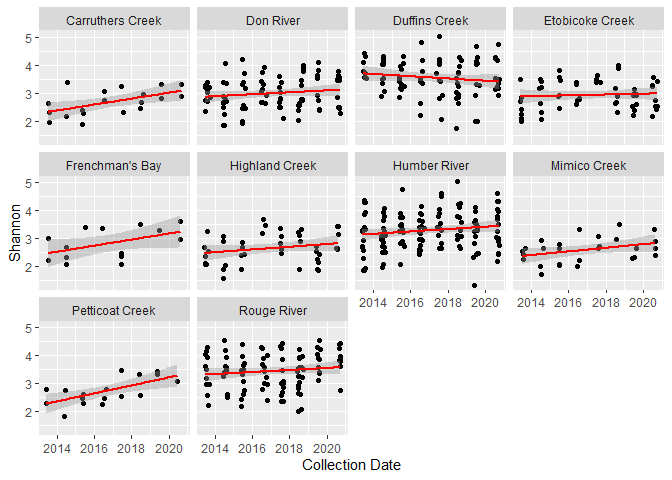

*Figure 3. Scatterplots depicting Shannon-Wiener Index across tested watersheds in the GTA during the period 2013-2020. NB:The higher the number, the more diverse the community.*

## 2.1 Sensitive Taxa

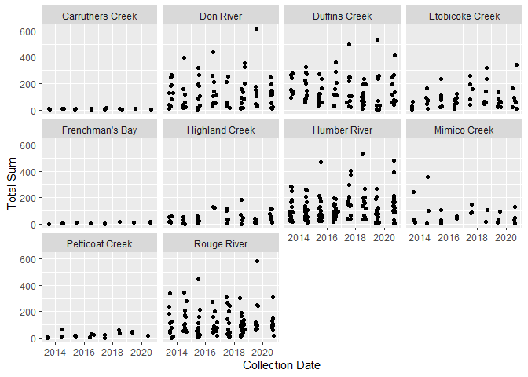

*Figure 4. Scatterplot for distribution and abundance of sensitive taxa, tricoptera, plecoptera and ephemeroptera*

Whilst there are numerous variables that can be found within the dataset, for the sake of simplicity, zinc, temperature and conductivity will be calculated and compared across the streams.

# 3 Dissolved Oxygen

With benthic macroinvertebrates, dissolved oxygen is of the utmost importance for such organisms. It serves as an indicator for the presence of benthic macrophytes and the lack thereof can serve as a warning that can give rise to algal blooms (Ogbeibu and Oribhabor 2002). Thus, such a parameter is very important to look at in terms of our it may affect communities across the GTA.

```
## Warning: Using `across()` in `filter()` is deprecated, use `if_any()` or
## `if_all()`.
```

```
## Warning: Removed 560 rows containing missing values (geom_point).
```

```
## Warning: Removed 32 rows containing missing values (geom_point).
```

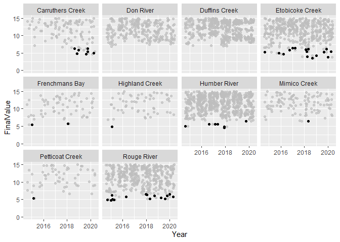

```r
#Loading data from csv files
read.csv("2015-wq-data-from-database-no-project-sites.csv") -> Data2015
read.csv("2016-wq-data-from-database-no-project-sites.csv") -> Data2016
read.csv("trca-2017-wq-data-rwmp-sites.csv") -> Data2017
read.csv("trca-2018-wq-data-rwmp-sites.csv") -> Data2018
read.csv("trca-2019-wq-data-rwmp-sites.csv") -> Data2019
read.csv("2020-wq-data-from-database-no-project-sites-1.csv") -> Data2020
#Extracting Dissolved Oxygen Data and removing uneccessary columns
Data2015[,c(5,10:12,13, 15:16)] %>% filter(ParameterDefinitionName == "Oxygen, Dissolved") -> DO15
Data2016[,c(5,10:12,13, 15:16)] %>% filter(ParameterDefinitionName == "Oxygen, Dissolved") -> DO16
Data2017[,c(3,8:11, 13:14)] %>% filter(ParameterDefinitionName == "Oxygen, Dissolved") -> DO17
Data2018[,c(5,10:12,13, 15:16)] %>% filter(ParameterDefinitionName == "Oxygen, Dissolved") -> DO18
Data2019[,c(5,10:12,13, 15:16)] %>% filter(ParameterDefinitionName == "Oxygen, Dissolved") -> DO19
Data2020[,c(5,10:12,13, 15:16)] %>% filter(ParameterDefinitionName == "Oxygen, Dissolved") -> DO20
#Coagulating all the data together
rbind(DO15,DO16, DO17, DO18, DO19, DO20) -> DO
#Graphing it
ggplot(DO) + geom_jitter(aes(Year, FinalValue))  + gghighlight(FinalValue < 6.5) + facet_wrap(~Watershed) + ylim(0,15)
```

_Figure 5. Scatterplot for dissolved oxygen (DO) values across the GTA over the period 2015-2020. Data highlighted indicates below expected DO values (< 6.5mg/L).

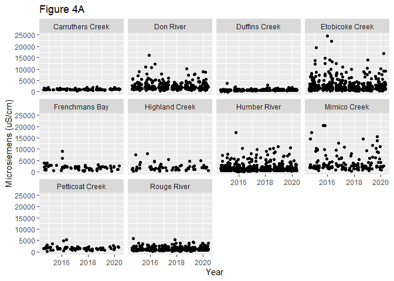

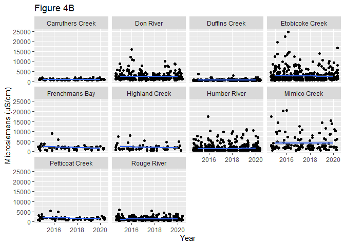

# 4 Zinc Levels

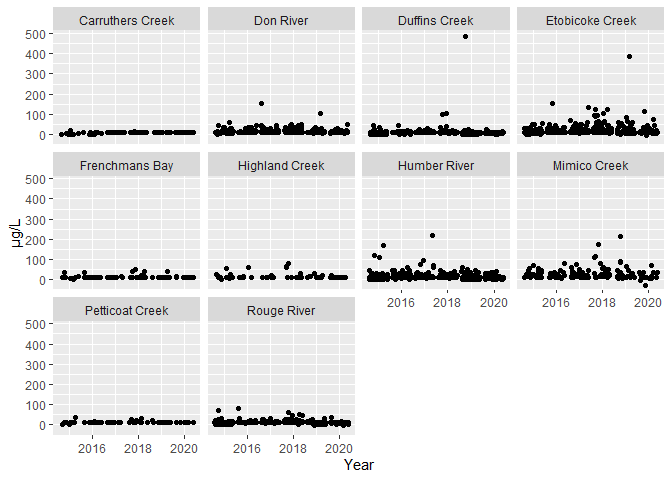

*Figure 6. Zinc concentrations for watersheds in the Greater Toronto Area.*

Heavy metals such as zinc have the potential to bioaccumulate in macroinvertebrates. In some cases, levels of trace metals found in surveyed organisms are equivalent to those found in nearby substrate (Goodyear and McNeil, 1999). Hence, Zinc levels in the water have been assessed accordingly. Going off surface water concentration guidelines set out by the Canadian Water Quality Guidelines for the Protection of Aquatic Life (2018), acceptable concentrations seem to sit between <2 to 537ug/L. Hence, trace amounts are expected to occur in any given waterbodies.

# 5 Temperature

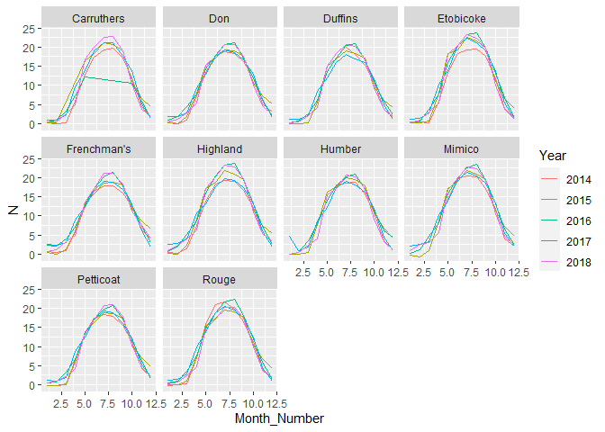

*Figure 7. Temperature changes over the period 2014-2018 in watersheds across the Greater Toronto Area.*

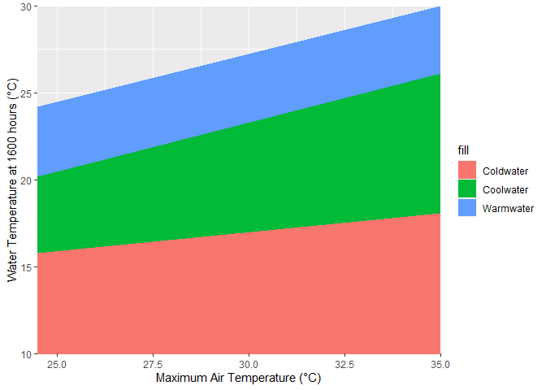

```r
#constructing the data frames necessary. Values taken approximately from original figure
a <- c(15.8, 18.1)
b <- c(20.2, 26.1)
c <- c(24.2, 30)
z <- c(24.5, 35) #base for the polygon in geom_area
Coldwater <- cbind(z, a) %>% data.frame()  #Taking each data set, transforming it into a data frame and binding it to the z co-ordinate to form a polygon within the graph
Coolwater <- cbind(z, b) %>% data.frame()
Warmwater <- cbind(z, c) %>% data.frame()
plot <- ggplot() + geom_area(data = Warmwater, aes(z, c, fill = "Warmwater"))+ geom_area(data = Coolwater, aes(z, b, fill = "Coolwater")) + geom_area(data = Coldwater, aes(z, a, fill = "Coldwater"))  + xlab("Maximum Air Temperature (°C)") + ylab("Water Temperature at 1600 hours (°C)") #plotting it all out now. Just need to adjust the y and x axis for discrete variables
plot +  coord_cartesian(ylim = c(10, 30), expand = FALSE) #Setting limits
```

# 6 Conclusion

Whilst macroinvertebrate communities show a wide variety of diverse taxa, the effects of urbanized streams becomes more apparent when certain watersheds show a lack of sensitive taxa as well as increasing temperatures and high levels of electrical conductivity. In order to tackle these problems, a number of solutions can be implemented which when compounded can reduce the effects of urban development on these systems. Riparian plantings can provide much needed shade as well as filtering out heavy metals travelling in soil. Additionally, for the most degraded environments, more active volunteering efforts to clean the perimeter of their respective watersheds such as Don River, Etobicoke and Humber will greatly benefit the ecology of the area.

References:

Bazinet, N. L., Gilbert, B. M., & Wallace, A. M. (2010). A comparison of urbanization effects on stream benthic macroinvertebrates and water chemistry in an urban and an urbanizing basin in Southern Ontario, Canada. Water Quality Research Journal, 45(3), 327-341.

Canadian Water Quality Guidelines for the Protection of Aquatic Life. (2018). Accessed April 8 2022 from https://ccme.ca/en/res/zinc-en-canadian-water-quality-guidelines-for-the-protection-of-aquatic-life.pdf.

Chu, C., Jones, N. E., Piggott, A. R., & Buttle, J. M. (2009). Evaluation of a simple method to classify the thermal characteristics of streams using a nomogram of daily maximum air and water temperatures. North American Journal of Fisheries Management, 29(6), 1605-1619.

Environment and Natural Resources Canada. (Date Unknown). https://www.enr.gov.nt.ca/sites/enr/files/conductivity.pdf.

Environmental Protection Agency. EPA (2012). Accessed April 9 2022 from https://archive.epa.gov/water/archive/web/html/vms59.html.

Goodyear, K. L., & McNeill, S. (1999). Bioaccumulation of heavy metals by aquatic macro-invertebrates of different feeding guilds: a review. Science of the Total Environment, 229(1-2), 1-19.

Jiang, X. M., Xiong, J., Qiu, J. W., Wu, J. M., Wang, J. W., & Xie, Z. C. (2010). Structure of macroinvertebrate communities in relation to environmental variables in a subtropical Asian river system. International Review of Hydrobiology, 95(1), 42-57.

Ontario Ministry for the Environment. (2012). Accessed March 20 2022 from https://www.ontario.ca/document/water-quality-15-streams-agricultural-watersheds-southwestern-ontario-2004-2009#section-5.

Qu, X., Tang, T., Xie, Z., Ye, L., Li, D., & Cai, Q. (2005). Distribution of the macroinvertebrate communities in the Xiangxi River system and relationships with environmental factors. Journal of Freshwater Ecology, 20(2), 233-238.

Stoneman, C. L., & Jones, M. L. (1996). A simple method to classify stream thermal stability with single observations of daily maximum water and air temperatures. North American Journal of Fisheries Management, 16(4), 728-737.

Thorne, R. S. J., Williams, W. P., & Gordon, C. (2000). The macroinvertebrates of a polluted stream in Ghana. Journal of Freshwater Ecology, 15(2), 209-217.

Toronto Regional Conservation Authority. (2021).Retrieved February 27 2022 from https://data.trca.ca/dataset?q=TRCA%E2%80%99s+Regional+Watershed+Monitoring+Program.

Wallace, A. M., Croft-White, M. V., & Moryk, J. (2013). Are Toronto’s streams sick? A look at the fish and benthic invertebrate communities in the Toronto region in relation to the urban stream syndrome. Environmental monitoring and assessment, 185(9), 7857-7875.